# Регрессионный анализ, часть 3. Домашнее задание, вариант 3.

## Регрессионный анализ, часть 3. Домашнее задание, вариант 3.

Кемпбелл и Махон изучали морфологическую изменчивость голубой и оранжевой форм крабов [Leptograpsus variegatus](http://en.wikipedia.org/wiki/Leptograpsus), обитающих в Австралии (Campbell, Mahon, 1974). Их интересовало, можно ли идентифицировать виды, используя морфологические характеристики, такие как ширина фронтальной и задней части карапакса, длина по медианной оси, максимальная ширина и толщина тела (рис. 1).

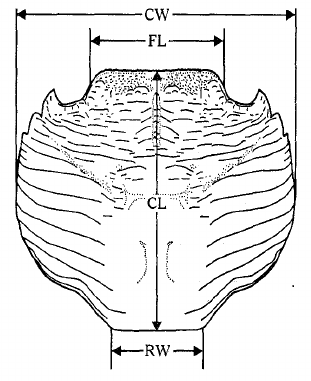

**Рис.1** Карапакс краба *Leptograpsus variegatus*, вид с дорсальной стороны. Отмечены измерения. **FL** - ширина фронтальной области кзади от передних фронтальных бугров, **RW** - ширина задней части, **CL** - длина по медианной оси, **CW** - максимальная ширина. Кроме отмеченных признаков, так же измеряли толщину тела (**BD**). (Из Campbell, Mahon, 1974)

Используйте линейную модель из предыдущего домашнего задания, чтобы проверить условия применимости линейной регрессии:

- Подберите линейную модель при помощи RMA-регрессии, чтобы описать зависимость длины карапакса по медианной оси от ширины задней части карапаксадля голубой формы крабов (данные в файле lept-b.xlsx и lept-b.csv).
- Постройте график RMA-регрессии с доверительными интервалами. Для сравнения добавьте линию простой линейной регрессии. Как расположены друг относительно друга эти линии?
- В отчете опишите ход анализа. Сделайте вывод о том, как выбор модели линейной регрессии влияет на оценки коэффициентов. Когда это может быть опасно, а когда - нет? Приложите работающий код, файл с рисунком и файл с подписью к рисунку. Подпись должна быть достаточно подробной, чтобы рисунок можно было понять в отрыве от основного текста.
- Незабудьте проверить все ли вы сделали - посмотрите критерии оценок в главном меню на сайте. Узнать, как правильно процитировать R можно, выполнив команду `citation()`

### Extra Credit

Укажите, какие графики линейной регрессии и графики остатков относятся к одним и тем же данным (рис. 2-3). За решение этой задачки можно будет заработать 8 дополнительных баллов (по 2 за каждую пару).

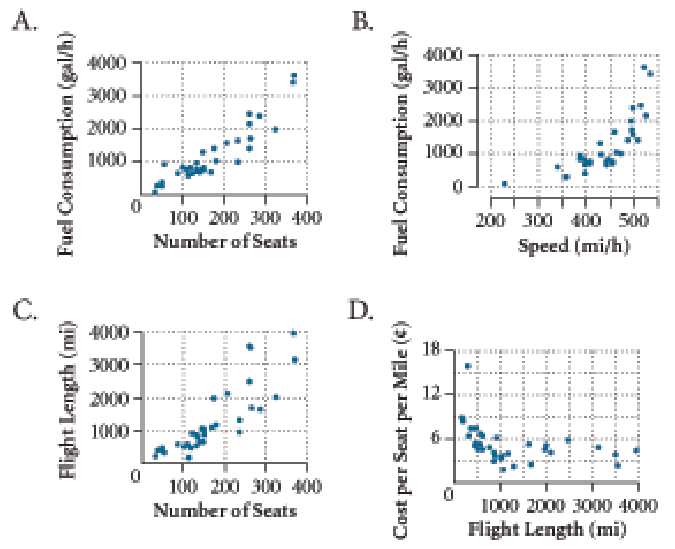

**Рис. 2.** Графики линейной регрессии

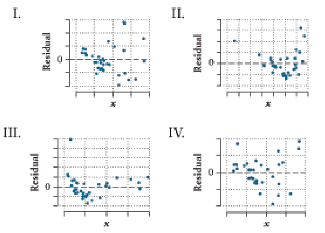

**Рис. 3.** Графики остатков от линейной регрессии